# Survival Analysis

Abdirasak Egeh

2024-11-14

# 1 Data

The dataset “pctrial.csv” consists of simulated data based on the Scottish Morbidity Record. This Record collects information on patients discharged from Scottish maternity hospitals.

### 1.0.1 Structure of the data

- trt: treatment group 0=standard of care, 1 = treatment
- time: time to death/censoring months
- event: status 0= censored, 1= dead

## 1.1 descripitve statistics

```
## 'data.frame':    36 obs. of  4 variables:
##  $ idno : int  1 2 3 4 5 6 7 8 9 10 ...
##  $ trt  : int  1 0 1 0 1 0 1 1 0 1 ...
##  $ time : int  41 16 36 45 27 7 2 48 40 39 ...
##  $ event: int  0 0 0 1 1 1 0 0 1 0 ...
```

```
## 'data.frame':    20 obs. of  1 variable:
##  $ event: int  0 0 0 0 0 0 0 0 0 0 ...
```

```
## 'data.frame':    18 obs. of  1 variable:
##  $ trt: int  0 0 0 0 0 0 0 0 0 0 ...
```

## 1.2 Kaplan Meier Curve

The Kaplan-Meier curve is used to estimate the survival function. According to the survival function, 50% of patients in the standard treatment group die at 30 months, whereas 70% experienced the event (death) at 45 months. Conversely, the median survival time for patients in the new treatment arm is 45 months, which is higher than that in the control or standard treatment arm.

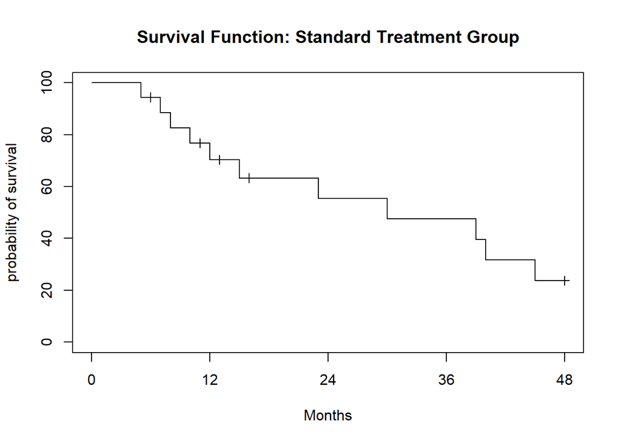

```
## 50
## 30
```

```
## 70
## 45
```

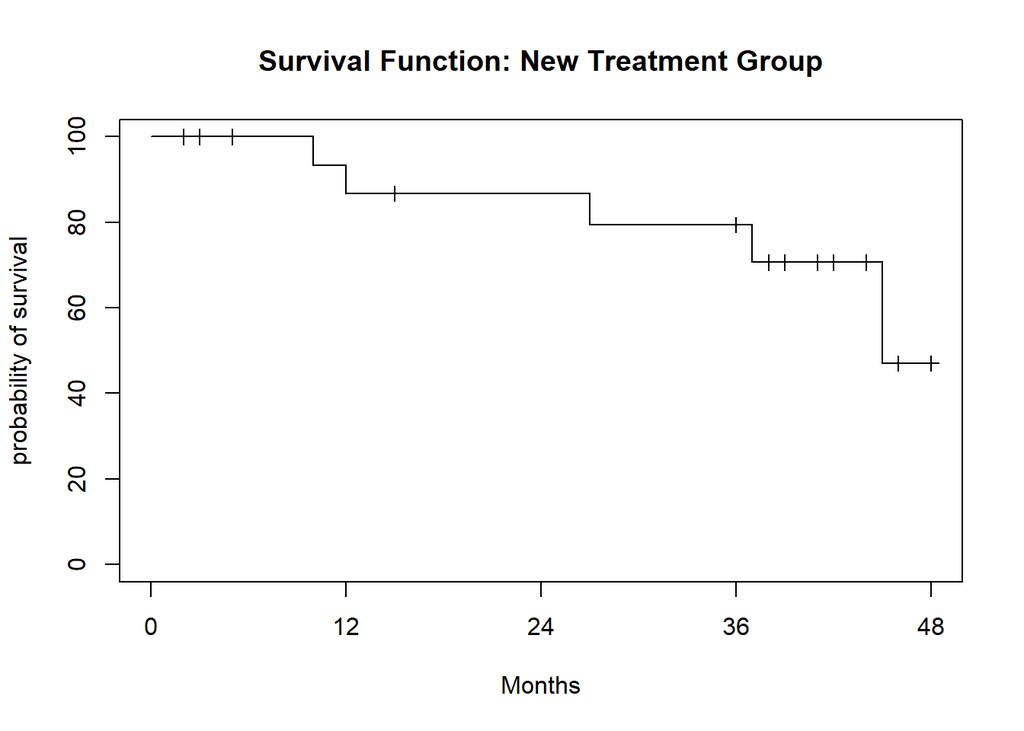

```
## 50
## 45
```

```
## 70
## NA
```